# COVID-19 Prediction using Explainable Machine Learning

## Background and Motivation

The COVID-19 or the SARS-CoV-2 originated from the district of Wuhan, China has transpired to be a pandemic worldwide [1]. Research on the COVID-19 is a hot topic among the Artificial Intelligence community recently. Due to shortage and limited efficiency of current testing mechanism of COVID-19 tests, i.e. through RT-PCR kits [2]; which usually takes upto 4-6 hours to reproduce the results is not very optimal way to move forward as the rate of COVID-19 patients registered grows exponentially. With this problem in scientific community, it motivated the aim of Machine Learning methods be brought to be a part in helping flattening the curve [3]. So, this lead to a goal of building classifiers which can diagonise patients as COVID-19 negative or positive based on their respective X-Ray images [4,5]. As this approach is less time and resource consuming; it is expected to achieve more streamlined performance compared to RT-PCR kits. Also in addition to a good prediction, we needed reasons that could justify what could be the features that are responsible in the diagonistic process [6].

With this idea and motivation in hand, our work tries to experiment in building classifiers with CXR (Chest X-Rays) as Ground Truth that predicts whether an X-Ray image is COVID-19 negative or positive. Along with, we try to come up with features that contributes to the detection of an image and also with an explaination delineating why was such a behaviour observed.

## Project Objective

With the motivation to help fight against and analyse COVID-19, we came up with a research question of whether

> Can we use Machine Learning methods to diagonise COVID-19 and explain the prediction?

To answer the this question, we aim to answer few sub-questions:

- How well could classifiers perform on Chest X-Rays?
- Although [2] and [6] extensively works with Neural Networks (Black-Box Model) to classify, Can simple and intrinsically explainable classifiers achieve a base Accuracy, F<sub>1</sub>-Score and AUC of 85% using CXR?
- How does different features of CXR contribute to the model prediction and Can we come up with few number of feature w.r.t their importance?
- Which flavour of algorithm perform best among all and is there a possibility of Classification in Ensemble setting?
- Can we come up with explaination of our model’s decsision and prediction?

## Dataset

Our Dataset consists of 313 Positive COVID CXR and 1000 Negative CXR collected from four different sources to make our version of the dataset to work upon. This includes COVIDx dataset of [6][^1], Kaggle CXR Pneumonia dataset by Paul Mooney,[^2] CXR images of adult subjects from the RSNA Pneumonia Detection Challenge,[^3] original and augmented versions of COVID-19 examples[^4] from [7].

According to [2,6,8–10] CT-Scan data would be gold-standard for us and also potray pretty good results evaluated in terms of Accuracy and F<sub>1</sub>-Score. However, due to CT Scan being available in very less quantity publicly, we would like to use Chest X-rays as our dataset. Though, it won’t be that competible in terms of quality w.r.t CT-Scans but [11] suggests CXR to be sufficient and comparable to CT-Scans in order to diagnose COVID-19 patients.

In particular we have used the [COVID-19 Dataset-Repo](https://shorturl.at/qwLR0) as our Ground Truth.

## Exploratory Data Analysis

### Data Exploration

Our Dataset consists of 313 Positive COVID CXR and 1000 Negative CXR collected from four different sources to make our version of the dataset to work upon. This includes COVIDx dataset of [6][^5], Kaggle CXR Pneumonia dataset by Paul Mooney,[^6] CXR images of adult subjects from the RSNA Pneumonia Detection Challenge,[^7] original and augmented versions of COVID-19 examples[^8] from [7].

```
## # A tibble: 1 x 7
##   format width height colorspace matte filesize density
##   <chr>  <int>  <int> <chr>      <lgl>    <int> <chr>
## 1 JPEG     657    735 sRGB       FALSE   101551 300x300
```

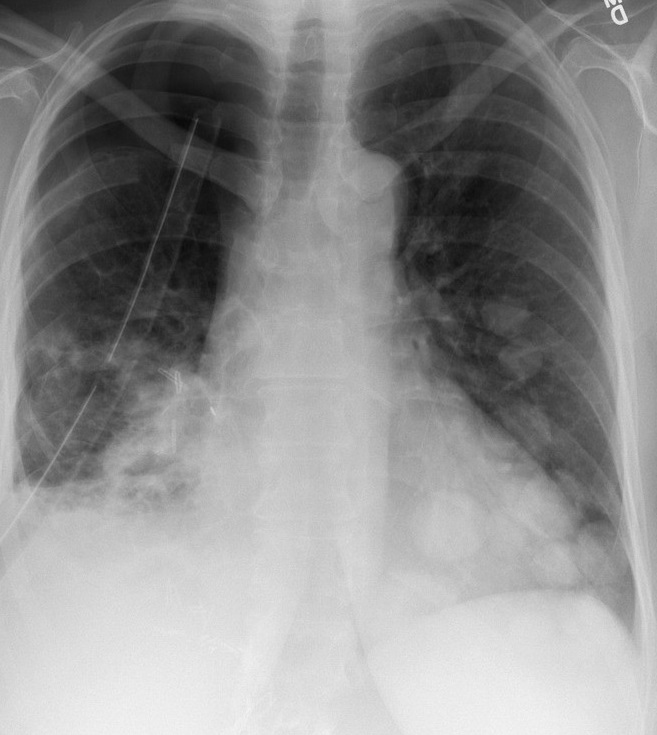

Real world datasets are mostly imbalanced. The COVID-19 CXR (Chest X-Rays) dataset we used has around 1000 to 313 negative to positive ratio. That there are nearly three times more negative cases than that of positive. The classification algorithms in this case tends to favor the majority class. The distribution of the classes in the dataset in reality refers to the actual class distribution of the covid affected cases. Hence, the learning task in hand is a imbalanced learning task because there are more people with healthy lungs than that of with COVID-19.

There are several methods to deal with this problem in classification setting, where the main objective is to rebalance the distribution by resampling the data to reduce the class imbalance problem, namely oversampling and under sampling. For our purpose we have used k fold cross-validation to train our model, where the data is split into multiple portions, and then (k-1) splits are used for training and 1 split for validation. And then this process is repeated several times.

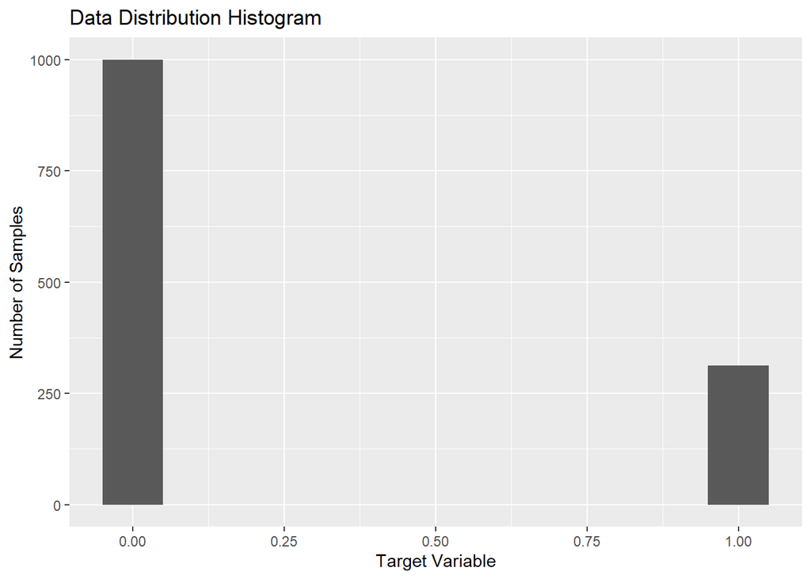

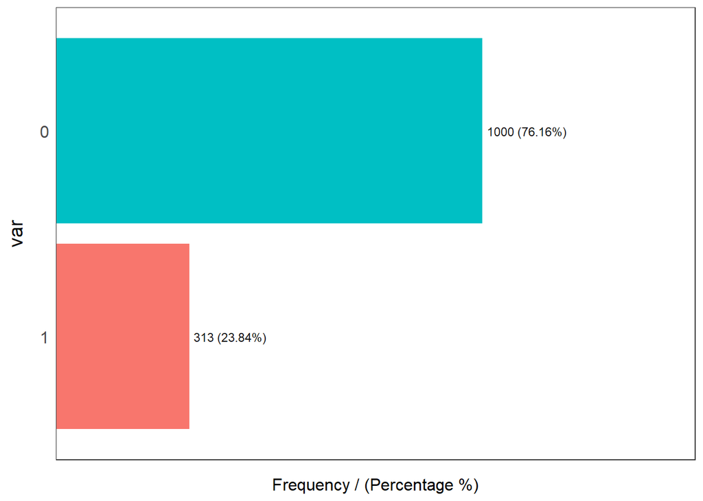

| var | frequency | percentage | cumulative_perc |
| --- | --- | --- | --- |
| 0 | 1000 | 76.16 | 76.16 |
| 1 | 313 | 23.84 | 100.00 |

Pie chart is the simplest representation of the dataset. This shows amount of images in percentage.

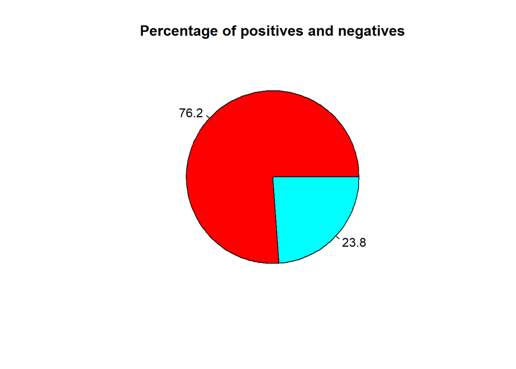

### Data Pre-processing

```
## # A tibble: 1 x 7
##   format width height colorspace matte filesize density
##   <chr>  <int>  <int> <chr>      <lgl>    <int> <chr>
## 1 JPEG     229    256 sRGB       FALSE        0 300x300
```

### Feature Extraction

For CXR images, the visual attribute that shows the most promising results are the texture based descriptors. There are several texture based descriptors that are available, both handcrafted and non handcrafted, however, we have focused mostly on the widely used Local Binary Patterns, formularized by [12].

LBP is a powerful texture descriptor, that has been applied on several classification tasks involving the texture. The LBP is calculated on a pixel to pixel basis by considering a center pixel(c) and its neighbourhood pixels (n) with some radius. Each neighbour pixel n is compared with center pixel c by means of substracting the grey values say g(c) and g(n) to get a distance d, such that if the d is negative then 0 is substituted in the place of the neighbour pixel else 1.

$$d = 1~~iff~~g(c)-g(n)≥0$$
$$d=0~otherwise$$

The descriptor is then the histogram of such which counts the occurrence of binary pattens. The histogram depends on the setup of the radius and the obviously the pixel neighborhood. LBP has been successfully tried on several classification techniques [13]

**Parameters:** Parameters used for the purpose are LBP <sub>8,2</sub> with 58 dimensions. The details of the parameters can be found in [12].

**Vectors:** As is previously explained there are total of 58 dimensions, to the descriptor. For a given CXR image we initially ran the descriptor on the complete image, and thus the descriptors obtained were very rich.

However, with this setting there is a problem, that the feature extractor not only captures the area of the lungs but the whole rib cage, which includes other organs too. Hence there is much noise considering our aim of getting the features our of the are of the lungs. For that purpose we used [segmentations](https://lmb.informatik.uni-freiburg.de/people/ronneber/u-net/) [14], to segment the area of the lungs our by means of a mask and then calculate the LBP for the masked area.

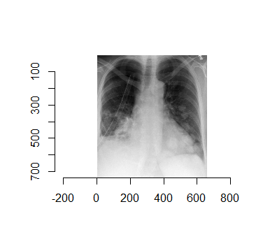

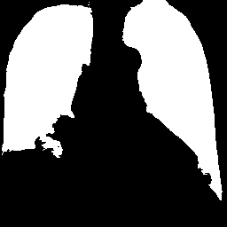

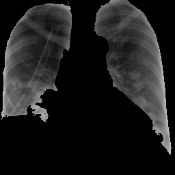

As expected in this case, the figure below shows some of the bins of the histogram are empty due to the usage of masking of the image.

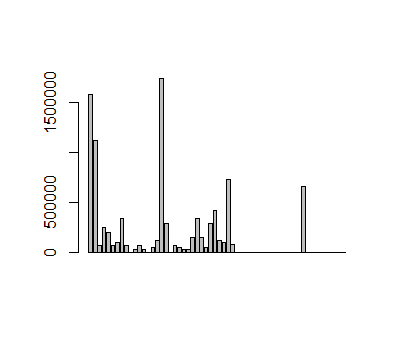

All the images are converted into grayscale because the Local Binary Pattern works only with grayscale images.

```
img <- grayscale(img)
```

The Algorithm converts the images into a data matrix and feds it into local binary function which creates the lbp vectors for the corresponding image.

```
imgm <- data.matrix(img)
lbpd <- lbp(imgm, 2)
```

Thereafter, it forms a dataframe of 1313 rows and 59 columns where 59th column being the Target Class with values `0` for COVID negatives and `1` for COVID positives.

| rows | columns | discrete_columns | continuous_columns | all_missing_columns | total_missing_values | complete_rows | total_observations | memory_usage |
| --- | --- | --- | --- | --- | --- | --- | --- | --- |
| 1313 | 59 | 0 | 59 | 0 | 0 | 1313 | 77467 | 631560 |

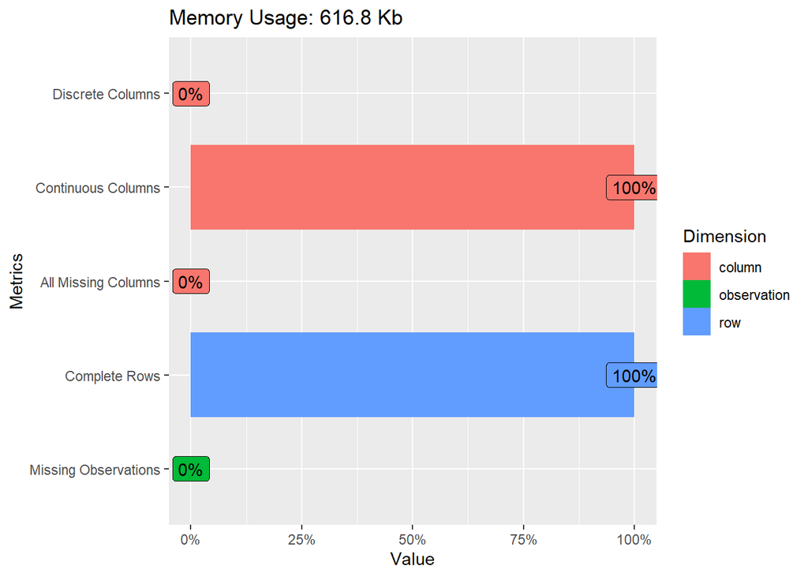

Since the real world data can be messy, the following plot below shows the missing values in columns. All the columns are kept nameless and are therefore by default named **“V#”** with its repective column number.

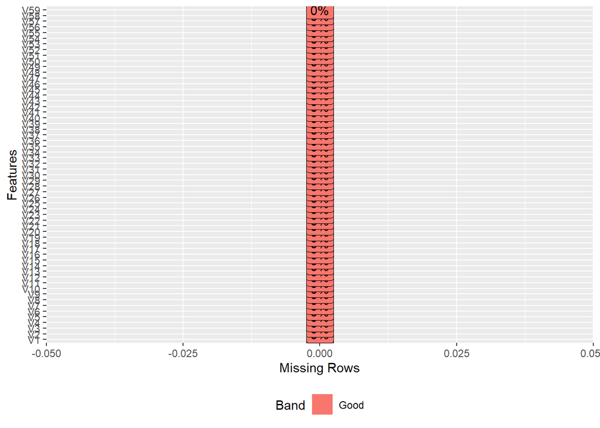

The figures below shows column-wise vector representation:

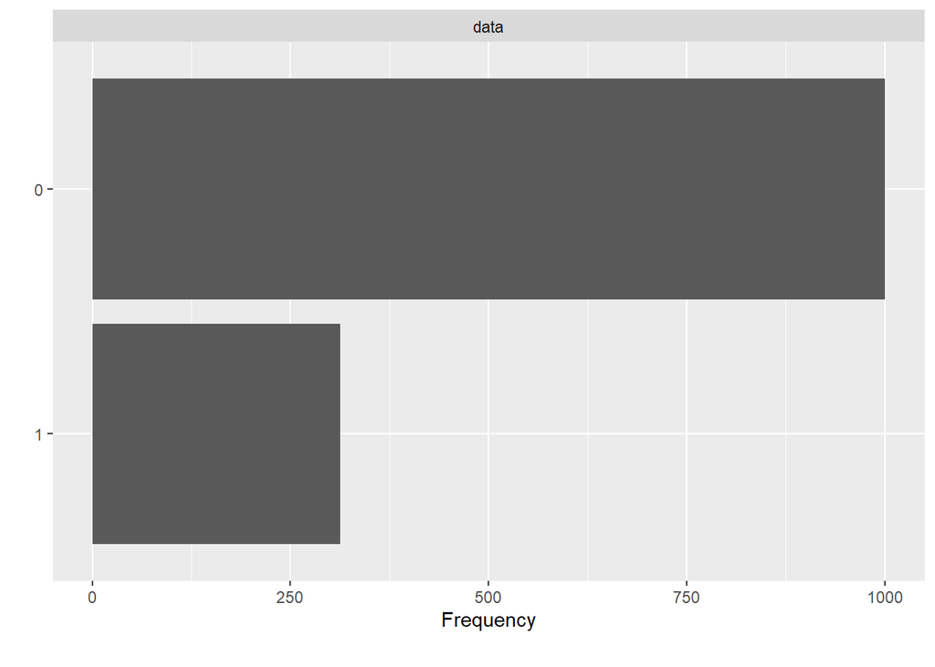

The following plot shows visualisation of distribution of lbp vector column-wise:

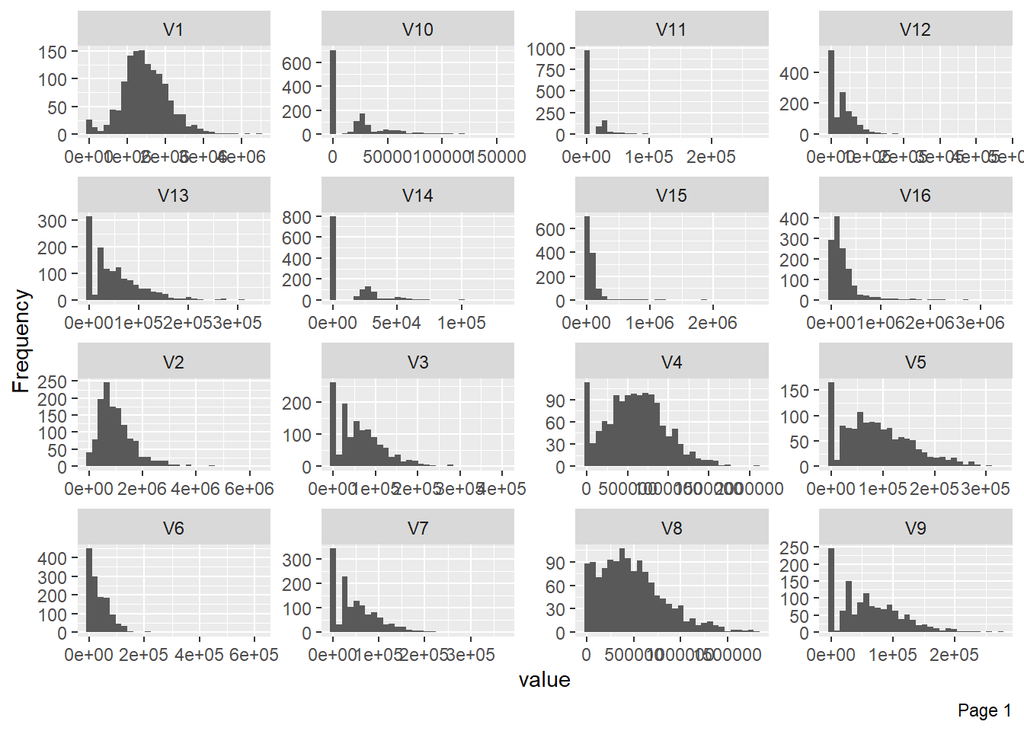

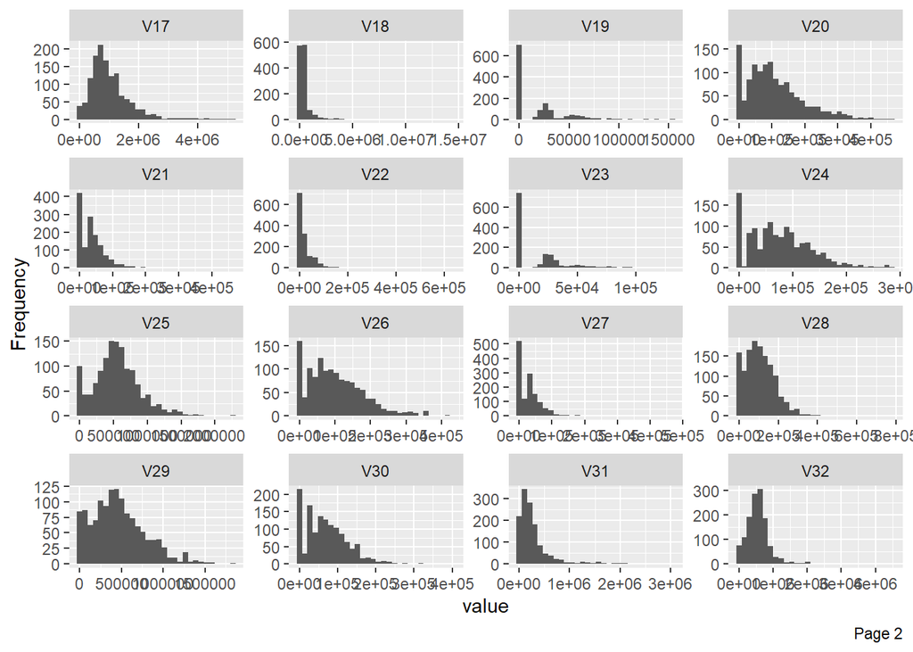

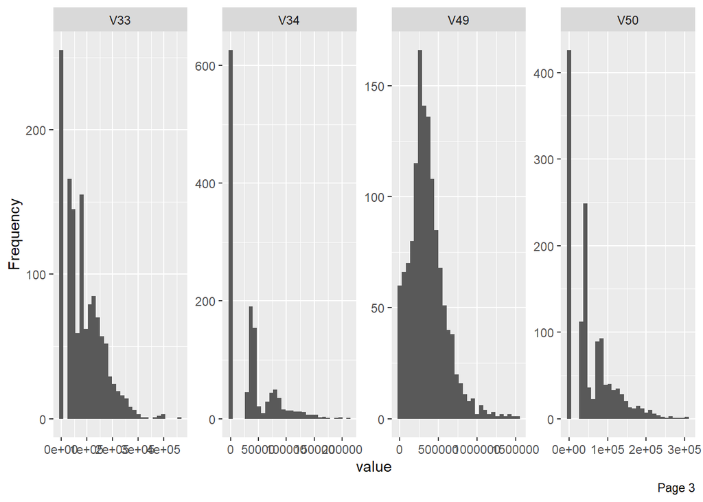

The figure below shows that very few columns vectors appears to be correlated. This is the case because the data has been masked.

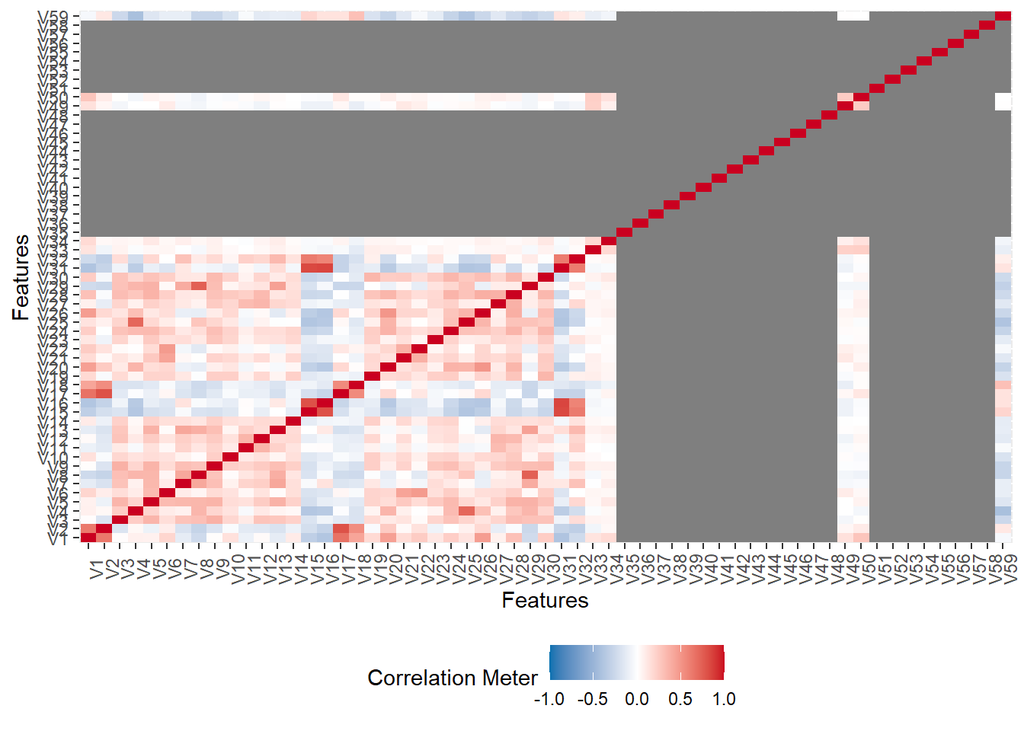

The figure shows Quantile-Quantile plot showing distribution of all the columns compared to normal distribution.

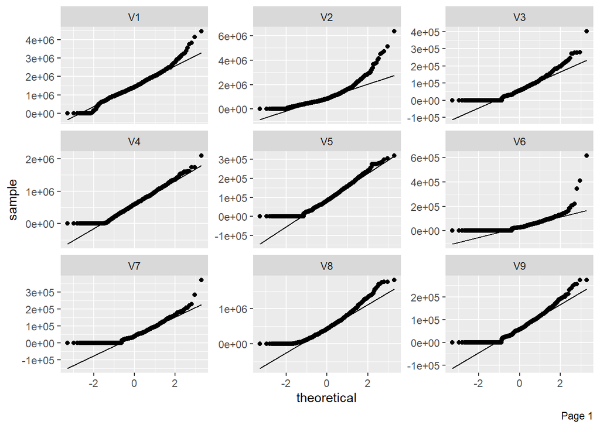

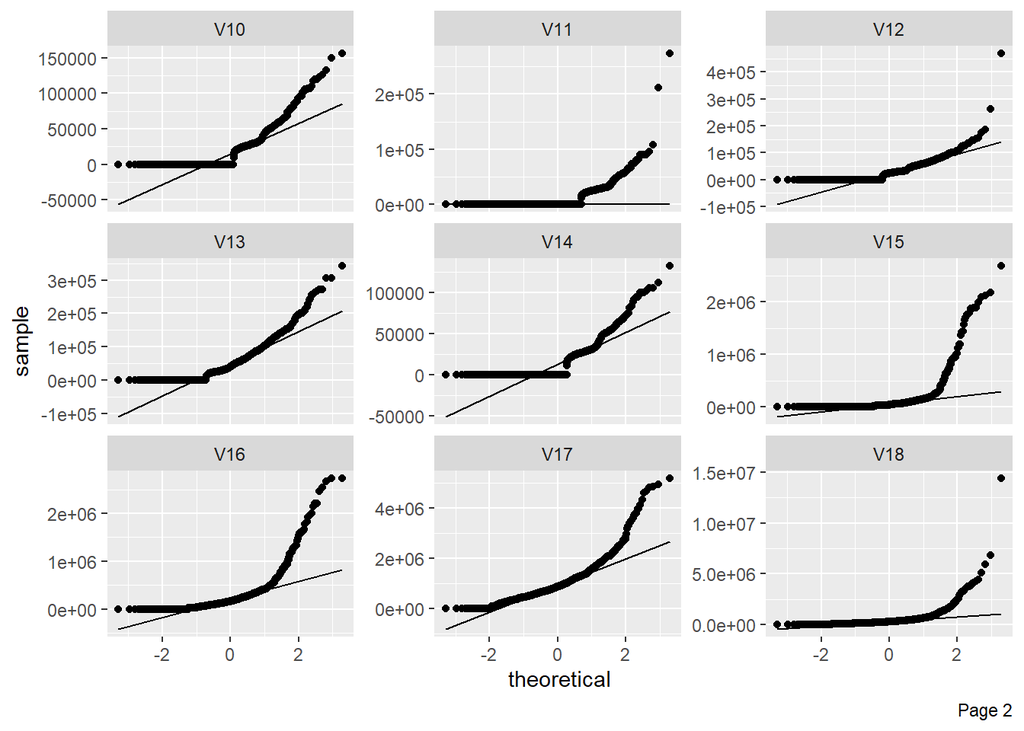

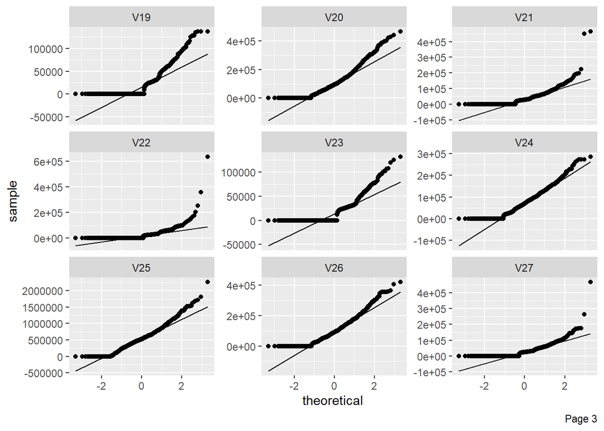

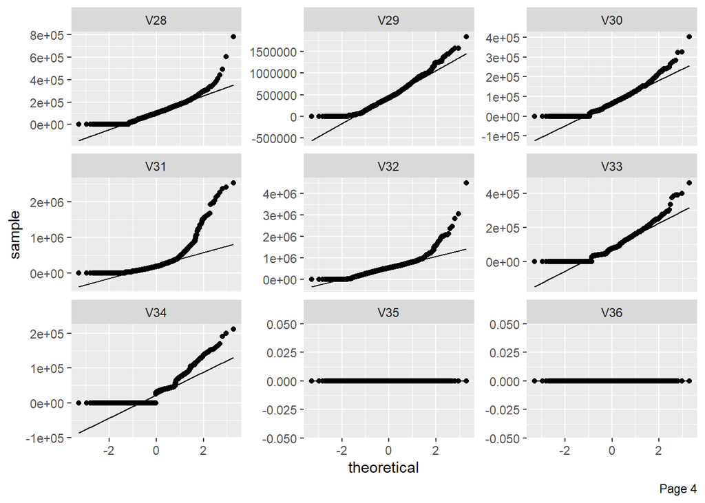

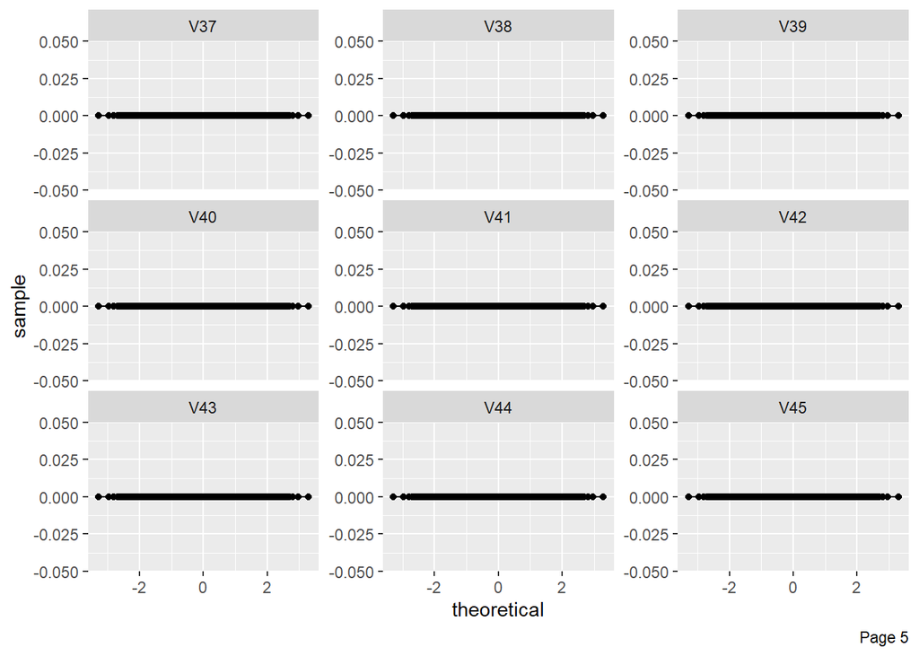

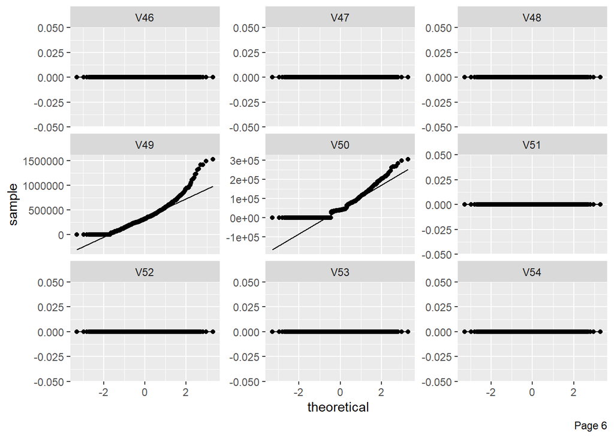

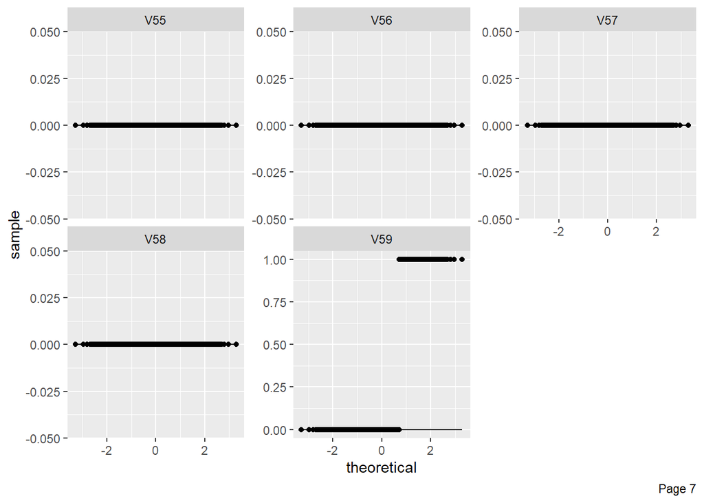

The following shows the variance in percentage for all the lbp vectors by **Principal Component Analysis**.

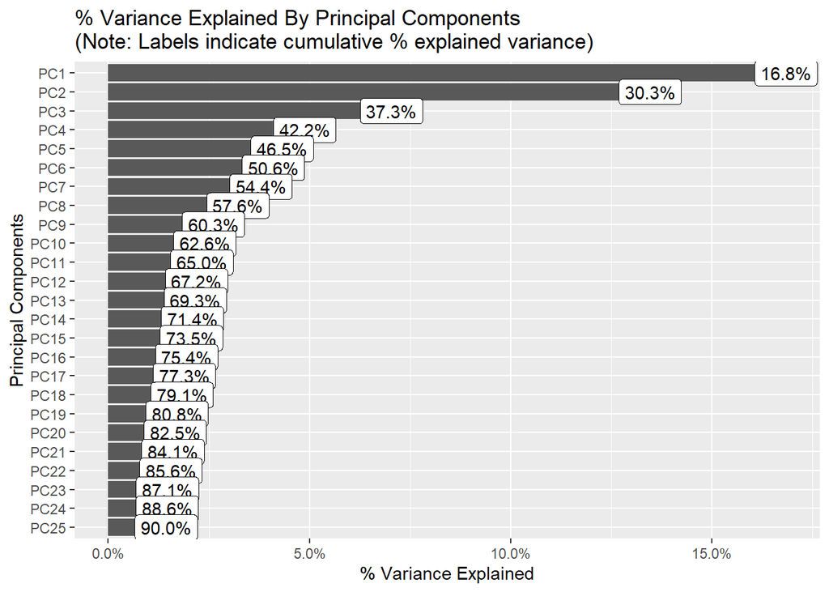

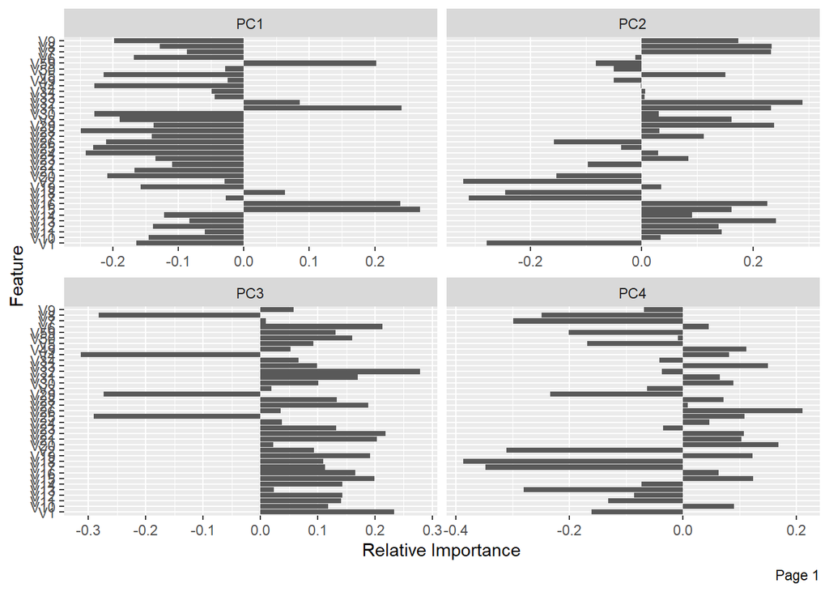

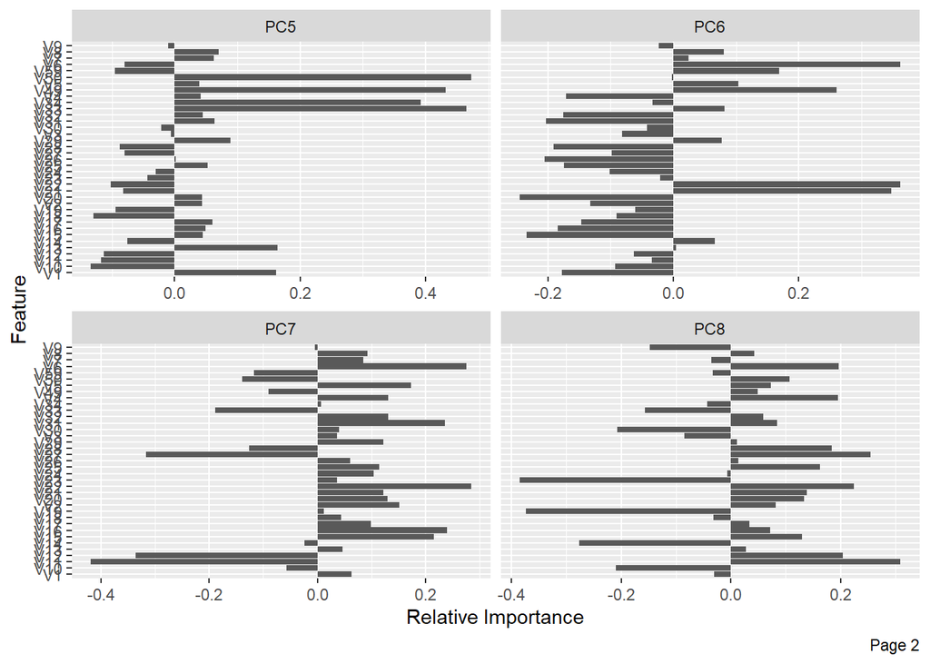

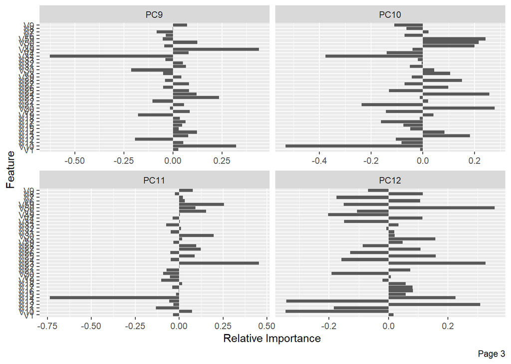

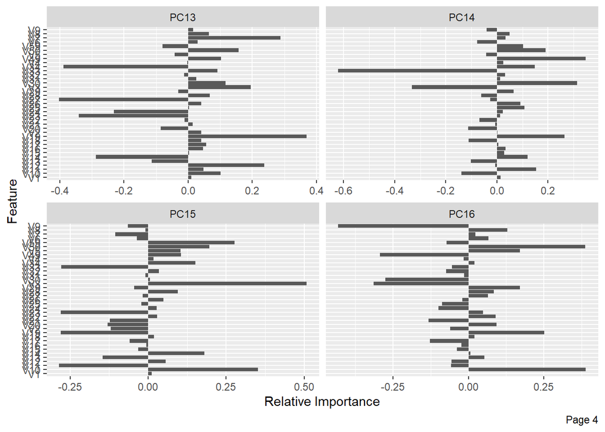

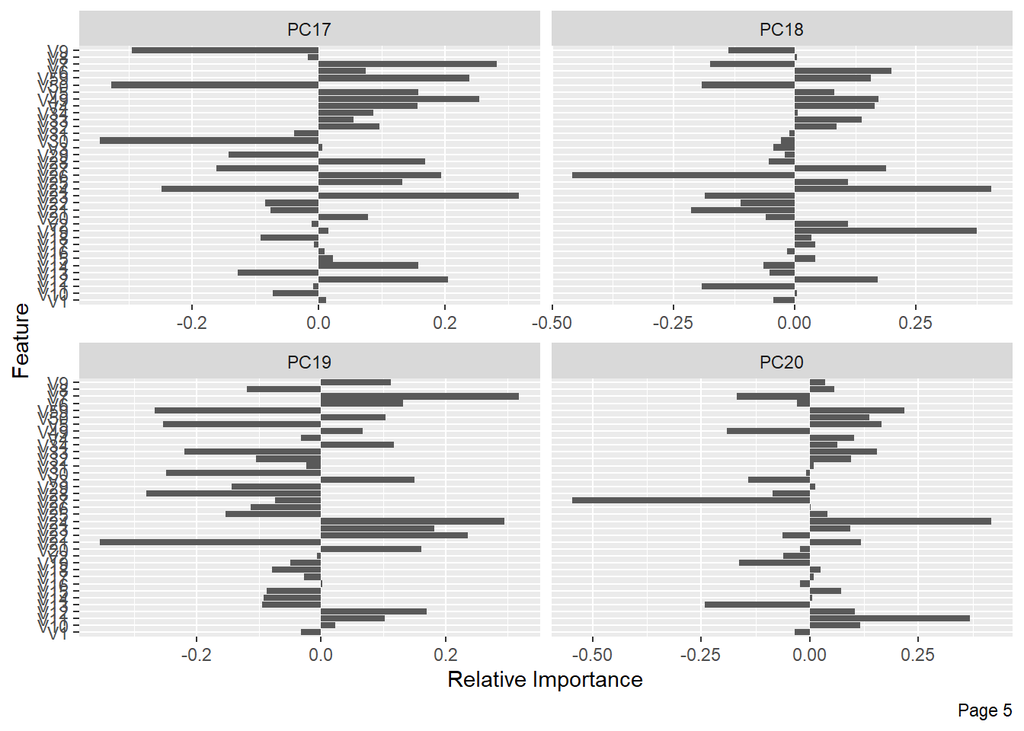

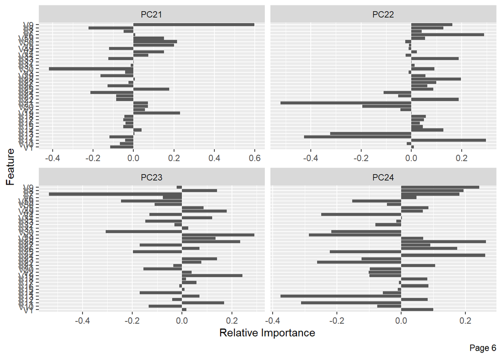

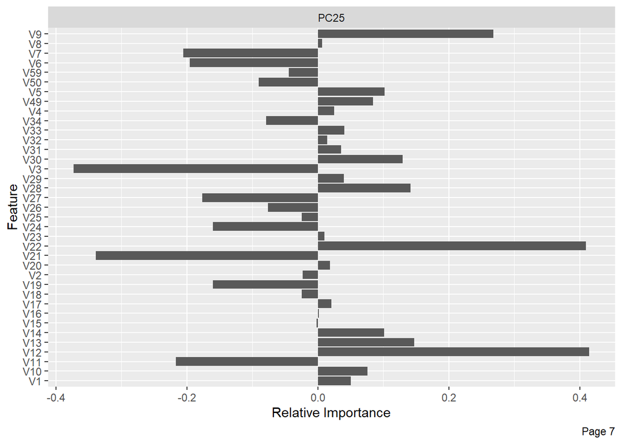